# Latihan 2

Putra Ramadhana

## Packages

```r
library(lmtest)   # uji Durbin-Watson
library(orcutt)   # metode Cochrane-Orcutt
```

1. **Plot sisaan** (sisaan vs urutan waktu / periode)
2. **Uji Durbin-Watson**

Jika ditemukan autokorelasi, dilakukan penanganan dengan dua metode:

- **Metode Cochrane-Orcutt** — mengestimasi $\rho$ (koefisien autokorelasi orde satu) secara iteratif menggunakan `orcutt::cochrane.orcutt()`, lalu mentransformasi data dengan $\rho$ tersebut.
- **Metode Hildreth-Lu** — mencari nilai $\rho$ optimum melalui pencarian grid (*grid search*) yang meminimumkan Jumlah Kuadrat Sisaan (JKS/SSE) dari model yang telah ditransformasi:

$$Y_t-\rho Y_{t-1}=\beta_0(1-\rho)+\beta_1(X_t-\rho X_{t-1})+\varepsilon_t$$

```r
# Fungsi Hildreth-Lu
hildreth.lu <- function(y, x, rho){
  t <- 2:length(y)
  y <- y[t] - rho * y[t-1]
  x <- x[t] - rho * x[t-1]
  return(lm(y ~ x))
}
```

# Data 2: Sales vs Advertising

## Impor Data

```r
Year <- 1975:2014
Sales <- c(11.7,12.0,12.3,12.8,13.1,13.6,13.9,14.4,14.7,15.3,
           15.5,15.8,16.1,16.6,16.9,16.7,16.9,17.4,17.6,17.9,
           18.0,17.9,18.0,18.2,18.2,18.3,18.6,19.2,19.3,19.5,
           19.2,19.3,19.5,20.0,20.0,19.9,19.8,19.9,20.2,21.0)
Advertising <- c(9.4,9.6,10.0,10.4,10.8,10.9,11.7,12.2,12.5,12.9,
                  13.0,13.2,13.8,14.2,14.6,14.4,15.0,15.4,15.7,15.9,
                  15.9,16.0,16.3,16.2,16.8,17.3,17.6,18.1,18.3,18.5,
                  18.7,18.9,19.2,20.0,20.0,20.3,20.4,21.0,21.5,22.1)
d2 <- data.frame(Year, Sales, Advertising)
d2
```

```
##    Year Sales Advertising
## 1  1975  11.7         9.4
## 2  1976  12.0         9.6
## 3  1977  12.3        10.0
## 4  1978  12.8        10.4
## 5  1979  13.1        10.8
## 6  1980  13.6        10.9
## 7  1981  13.9        11.7
## 8  1982  14.4        12.2
## 9  1983  14.7        12.5
## 10 1984  15.3        12.9
## 11 1985  15.5        13.0
## 12 1986  15.8        13.2
## 13 1987  16.1        13.8
## 14 1988  16.6        14.2
```

[output cut: 26 more lines]

## Regresi OLS (Cross Section)

```r
model2 <- lm(Sales ~ Advertising, data = d2)
summary(model2)
```

```
##
## Call:
## lm(formula = Sales ~ Advertising, data = d2)
##
## Residuals:
##      Min       1Q   Median       3Q      Max
## -1.03758 -0.40343  0.08933  0.45674  0.74036
##
## Coefficients:
##             Estimate Std. Error t value Pr(>|t|)
## (Intercept)  5.96513    0.38092   15.66   <2e-16 ***
## Advertising  0.71035    0.02365   30.04   <2e-16 ***
## ---
## Signif. codes:  0 '***' 0.001 '**' 0.01 '*' 0.05 '.' 0.1 ' ' 1
##
## Residual standard error: 0.527 on 38 degrees of freedom
## Multiple R-squared:  0.9596, Adjusted R-squared:  0.9585
## F-statistic: 902.3 on 1 and 38 DF,  p-value: < 2.2e-16
```

Model awal:

$$\hat{Sales} = 5.965 + 0.710\,Advertising$$

Model ini sangat signifikan ($p<0.001$) dengan $R^2 = 0.9596$.

## Deteksi Autokorelasi

### Plot Sisaan

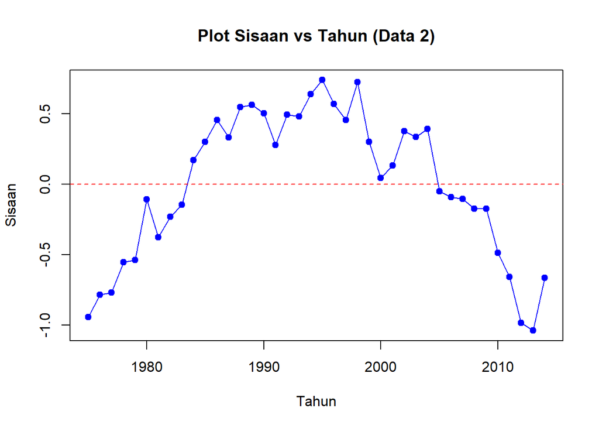

```r
plot(d2$Year, residuals(model2), type = "o", pch = 19, col = "blue",
     xlab = "Tahun", ylab = "Sisaan", main = "Plot Sisaan vs Tahun (Data 2)")
abline(h = 0, col = "red", lty = 2)
```

### Uji Durbin-Watson

```r
dwtest(model2)
```

```
##
##  Durbin-Watson test
##
## data:  model2
## DW = 0.16204, p-value < 2.2e-16
## alternative hypothesis: true autocorrelation is greater than 0
```

Nilai $DW = 0.162$ jauh di bawah 2 dengan $p$*-value* $\approx 0 < 0.05$. **Kesimpulan: autokorelasi positif yang sangat kuat terdeteksi**, jauh lebih parah dibandingkan Data 1, sehingga wajib ditangani.

## Penanganan Autokorelasi

### Metode 1: Cochrane-Orcutt

```r
model2.co <- cochrane.orcutt(model2)
model2.co
```

```
## Cochrane-orcutt estimation for first order autocorrelation
##
## Call:
## lm(formula = Sales ~ Advertising, data = d2)
##
##  number of interaction: 39
##  rho 0.903123
##
## Durbin-Watson statistic
## (original):    0.16204 , p-value: 8.935e-20
## (transformed): 1.93925 , p-value: 3.78e-01
##
##  coefficients:
## (Intercept) Advertising
##   10.252375    0.488489
```

Diperoleh $\rho = 0.9031$ (sangat tinggi, sesuai indikasi autokorelasi kuat sebelumnya). Setelah transformasi, DW naik dari 0.162 menjadi **1.939** ($p=0.378>0.05$) — autokorelasi berhasil **tertangani**. Model akhir:

$$\hat{Sales} = 10.252 + 0.488\,Advertising$$

### Metode 2: Hildreth-Lu

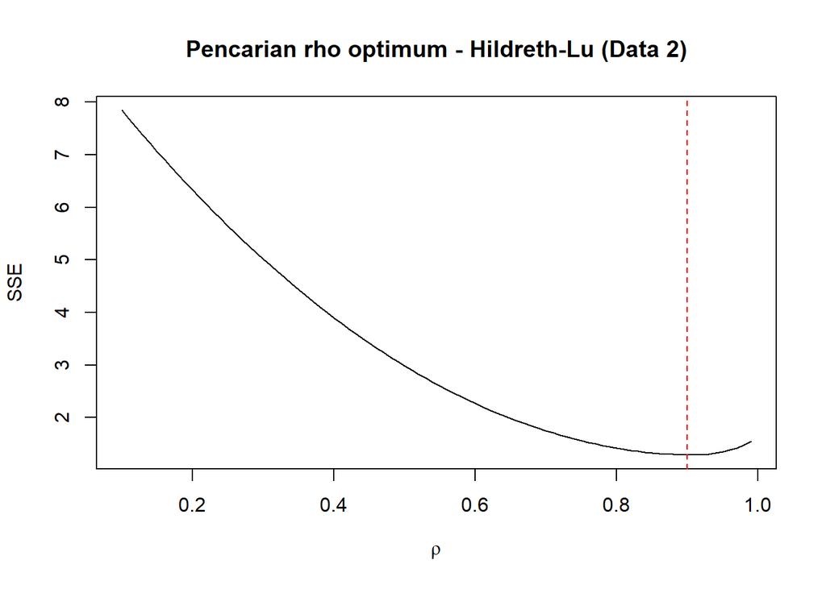

```r
rho2 <- seq(0.1, 0.99, 0.01)
SSE2 <- sapply(rho2, function(r) sum(residuals(hildreth.lu(d2$Sales, d2$Advertising, r))^2))

tab2 <- data.frame(rho2, SSE2)
plot(tab2$rho2, tab2$SSE2, type = "l", xlab = expression(rho), ylab = "SSE",
     main = "Pencarian rho optimum - Hildreth-Lu (Data 2)")
rho2.opt <- tab2$rho2[which.min(tab2$SSE2)]
abline(v = rho2.opt, col = "red", lty = 2)
```

```r
rho2.opt
```

```
## [1] 0.9
```

```r
model2.hl <- hildreth.lu(d2$Sales, d2$Advertising, rho2.opt)
summary(model2.hl)
```

```
##
## Call:
## lm(formula = y ~ x)
##
## Residuals:
##     Min      1Q  Median      3Q     Max
## -0.3749 -0.1461  0.0148  0.1057  0.4496
##
## Coefficients:
##             Estimate Std. Error t value Pr(>|t|)
## (Intercept)  1.01310    0.14198   7.135 1.87e-08 ***
## x            0.49358    0.07379   6.689 7.38e-08 ***
## ---
## Signif. codes:  0 '***' 0.001 '**' 0.01 '*' 0.05 '.' 0.1 ' ' 1
##
## Residual standard error: 0.1868 on 37 degrees of freedom
## Multiple R-squared:  0.5474, Adjusted R-squared:  0.5351
## F-statistic: 44.74 on 1 and 37 DF,  p-value: 7.382e-08
```

```r
intercept2.hl <- coef(model2.hl)[1] / (1 - rho2.opt)
cat("Intersep model asli:", intercept2.hl, "\n")
```

```
## Intersep model asli: 10.13098
```

```r
cat("Slope Advertising:", coef(model2.hl)[2], "\n")
```

```
## Slope Advertising: 0.4935821
```

```r
dwtest(model2.hl)
```

```
##
##  Durbin-Watson test
##
## data:  model2.hl
## DW = 1.9402, p-value = 0.3782
## alternative hypothesis: true autocorrelation is greater than 0
```

$\rho$ optimum Hildreth-Lu (**0.9**) sama persis dengan hasil Cochrane-Orcutt (dibulatkan 2 desimal). Setelah transformasi, DW menjadi **1.940** ($p=0.378>0.05$), autokorelasi tertangani, dengan model akhir:

$$\hat{Sales} = 10.131 + 0.494\,Advertising$$

## Kesimpulan Data 2

Data 2 menunjukkan autokorelasi yang **jauh lebih kuat** daripada Data 1 ($\rho\approx0.90$ dibanding $\rho\approx0.43$) — wajar karena *Sales* dan *Advertising* sama-sama memiliki tren naik yang sangat mulus sepanjang 40 tahun. Kedua metode penanganan (Cochrane-Orcutt dan Hildreth-Lu) memberikan hasil yang konsisten dan sama-sama berhasil menghilangkan autokorelasi. Model akhir yang direkomendasikan:

$$\hat{Sales} \approx 10.19 + 0.491\,Advertising$$